# ROP-VL EDA

Jaxon Lara

2026-10-06

# Data sources

- [Description](https://www.nature.com/articles/s41597-026-07901-0#additional-information)
- [Download](https://figshare.com/articles/dataset/ROP-VL_An_Open_Dataset_Integrating_Fundus_Photograph_and_Clinical_Knowledge_for_Retinopathy_of_Prematurity/30143461/1?file=58329352)

# What is ROP?

Retinopathy of prematurity is an eye disease affecting premature infants  
where abnormal blood vessels grow in the retina,  
potentially leading to retinal detachment and vision loss.

# Normal

healthy; no findings; no lesion signs;  
no retinopathy; incomplete vascularization.

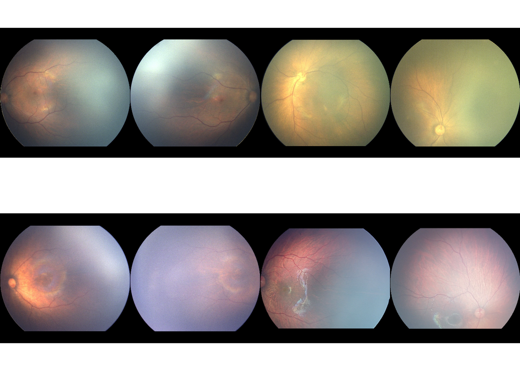

# Stage 1

a thin white line at the vascular-avascular junction  
with possible abnormal vessel branching.

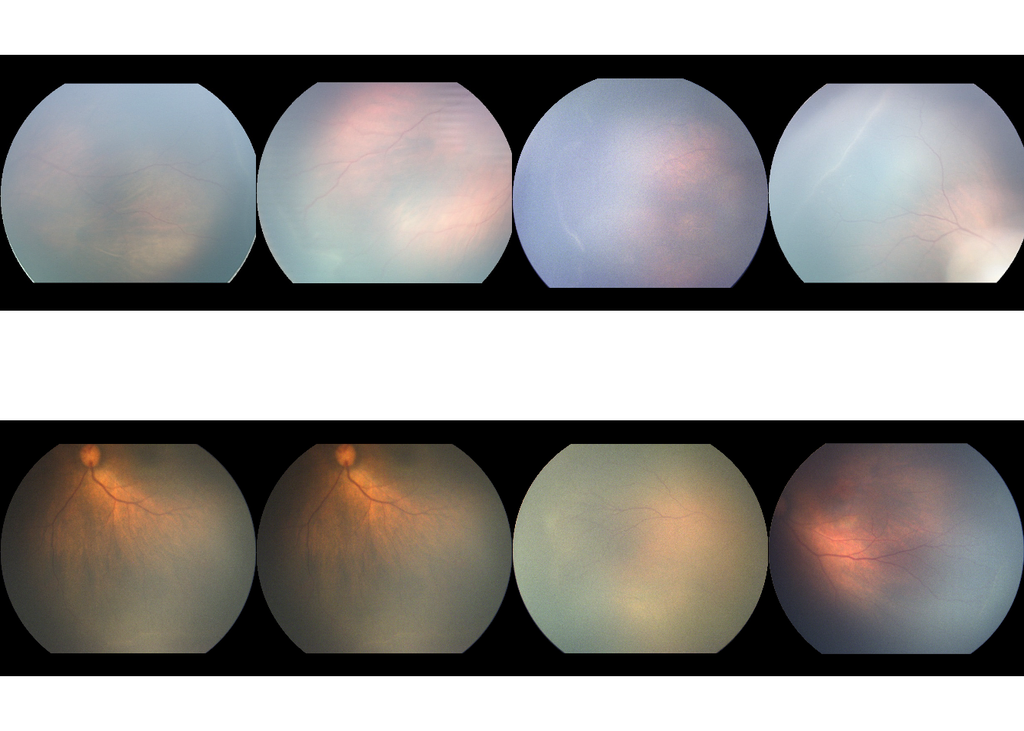

# Stage 2

ridge with width and height that evolves from the demarcation line;  
the ridge may vary in height; the ridge’s color ranges from white to pink;  
small isolated tufts of neovascular tissue lying on the surface of the retina;  
ridge is raised and thicker than stage 1 ROP.

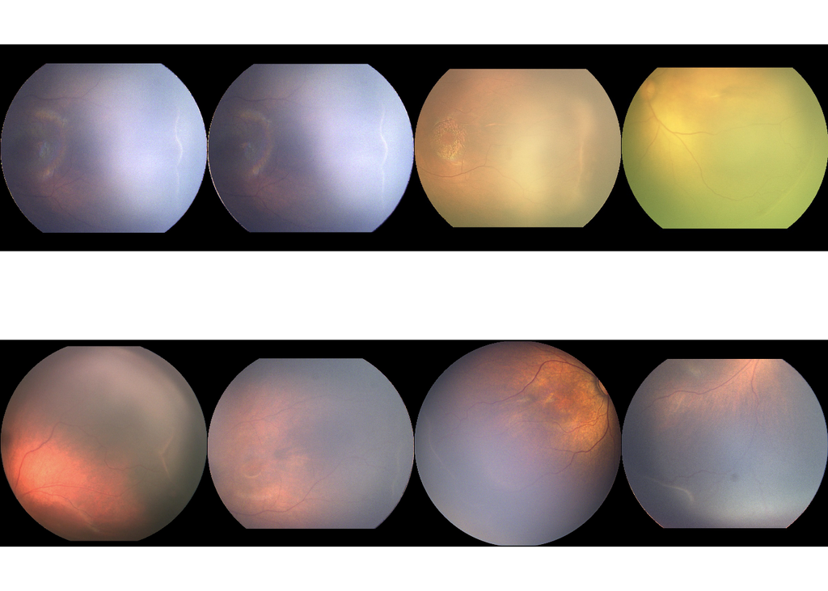

# Stage 3

extraretinal neovascular proliferation extends from the ridge into the vitreous;  
is continuous with the posterior aspect of the ridge, causing a ragged appearance as  
proliferation becomes more extensive; Seemingly flat-appearing extraretinal neovascularization  
can occur in eyes with zone 1 or posterior zone 2 disease,in the absence  
of an obvious ridge or demarcation line.

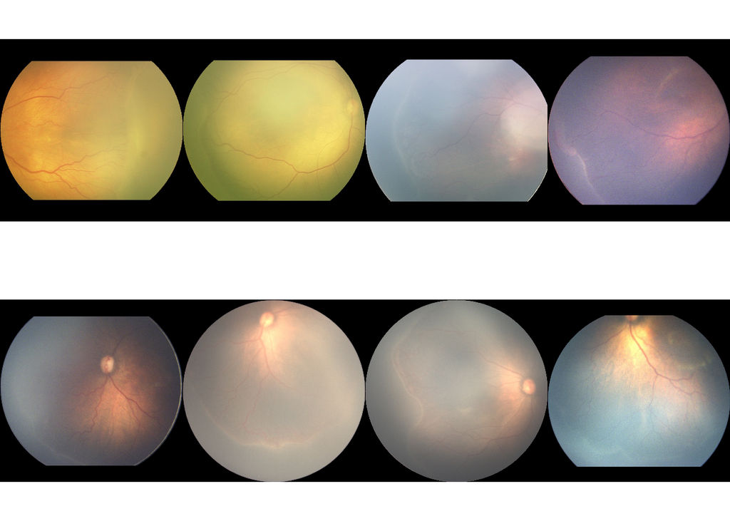

# Stage 4

partial retinal detachment, either spares or involves the fovea;  
traction on extraretinal neovascularization leads to retinal elevation;  
tractional retinal detachment in the area of the peripheral ridge;  
detachment involving the macula; detachment with associated subretinal  
hemorrhage and lipid exudation into the macula; detachment of  
vascularized retina into a volcano shaped configuration.

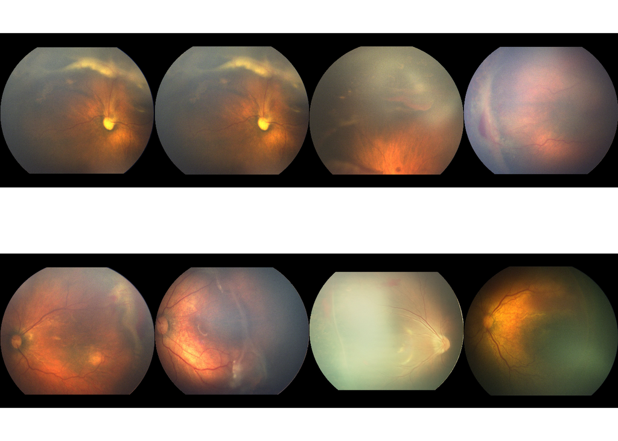

# Stage 5

total retinal detachment; open-funnel detachment, the optic disc is visible by ophthalmoscopy;  
closed-funnel detachment, the optic disc is not visible secondary;  
the optic disc is not visible secondary to retrolental fibrovascular tissue.

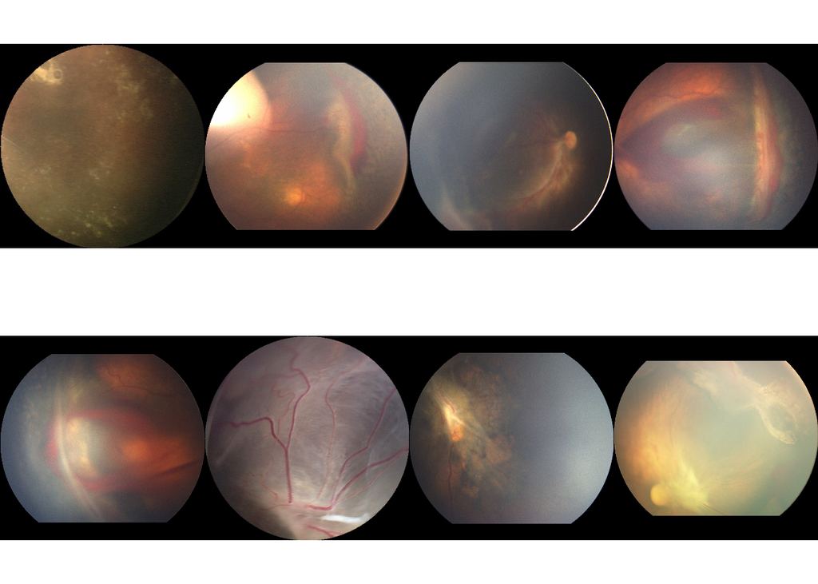

# A-ROP (aggressive retinopathy of prematurity)

severe vasoconstriction; capillary nonperfusion; nonphysiologic dilated vascular loops;  
arteriovenous shunts; plus disease in zone 1; dilated vascular loops; diffuse flat  
extraretinal neovascularization most prominent superotemporally, and severe plus disease;  
flat extraretinal neovascularization with fibrosis, and early contraction superiorly;  
intraretinal and vitreous hemorrhage superotemporally; ill-defined junction between  
vascular and avascular retina in zone 1.

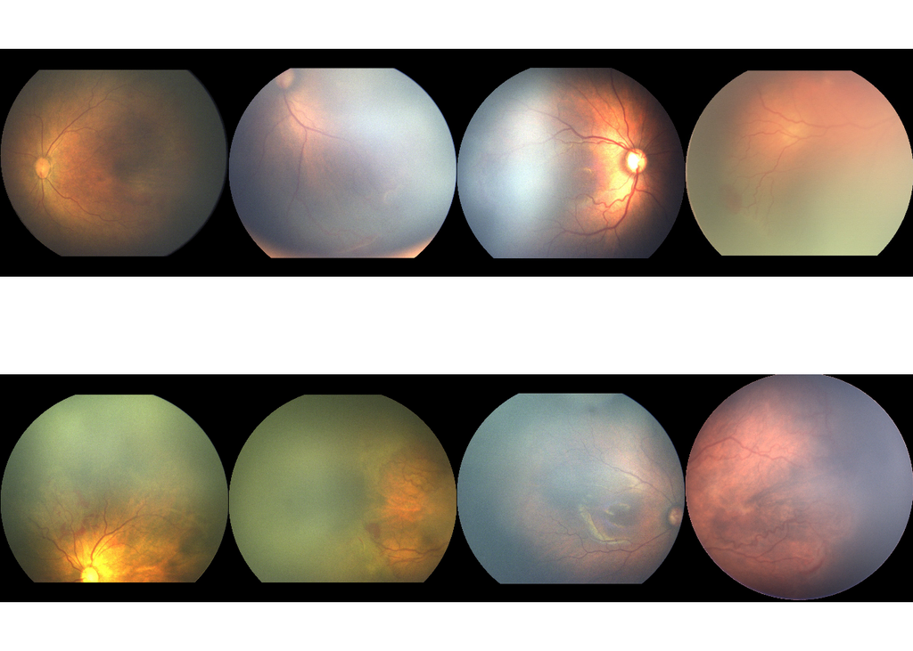

# Laser-treated ROP

laser scar; Laser spots look like small white dots on the retina,  
these are tiny burn marks; clear white retinal laser spots.

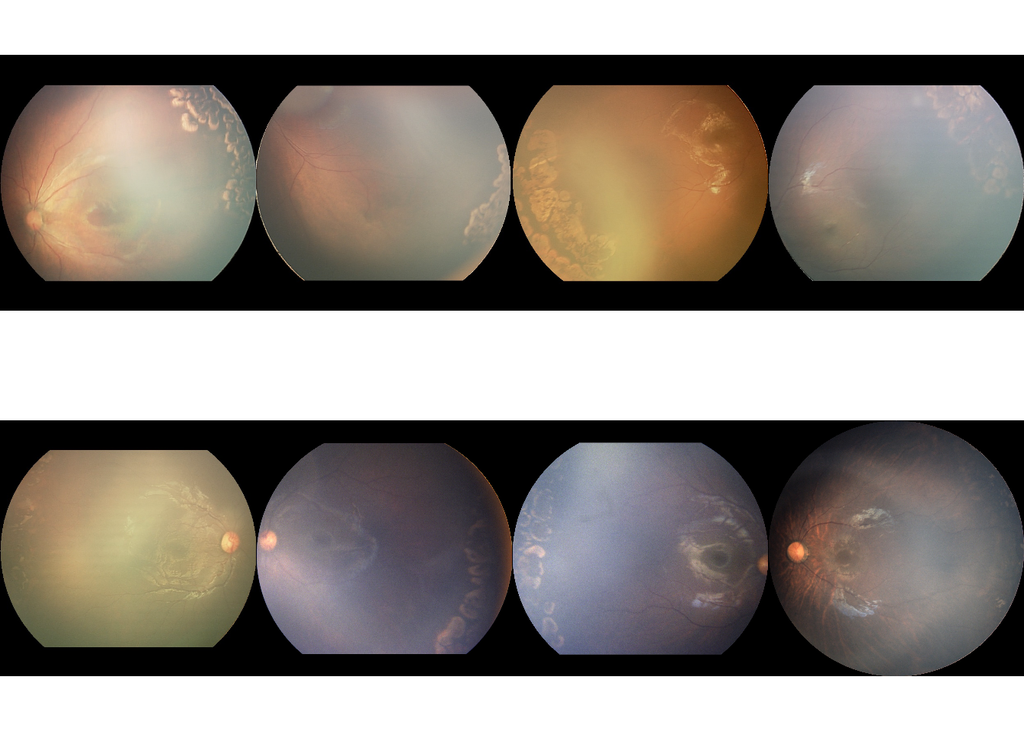